# Reproducible Research Week 2

Meri

10/07/2020

## Loading and preparing the data

```r
unzip("Activity Monitoring Data.zip")
mydata <- read.csv("activity.csv", header=TRUE)
summary(mydata)
```

```
##      steps            date              interval
##  Min.   :  0.00   Length:17568       Min.   :   0.0
##  1st Qu.:  0.00   Class :character   1st Qu.: 588.8
##  Median :  0.00   Mode  :character   Median :1177.5
##  Mean   : 37.38                      Mean   :1177.5
##  3rd Qu.: 12.00                      3rd Qu.:1766.2
##  Max.   :806.00                      Max.   :2355.0
##  NA's   :2304
```

## Task 1: What is the mean total number of steps taken per day?

Firstly, caclulate the total number of steps taken per day

```r
StepsEachDay <- aggregate(mydata$steps, list(mydata$date), FUN=sum)
colnames(StepsEachDay) <- c("Date", "Steps")
```

Following this, create a histogram of the total number of steps per day

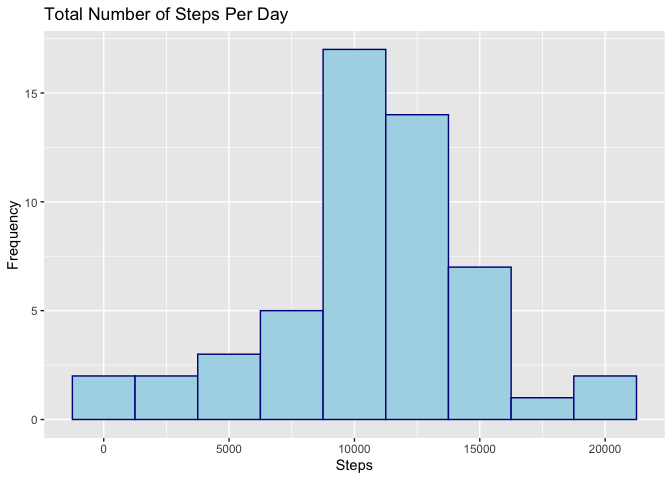

```r
g <- ggplot(StepsEachDay, aes(Steps))
g+geom_histogram(fill="light blue", col="dark blue", binwidth = 2500)+ggtitle("Total Number of Steps Per Day")+xlab("Steps")+ylab("Frequency")
```

Lastly, calculate the mean and median values of total number of steps each day

```r
mean(StepsEachDay$Steps, na.rm=TRUE)
```

```
## [1] 10766.19
```

```r
median(StepsEachDay$Steps, na.rm=TRUE)
```

```
## [1] 10765
```

## Task 2: What is the average daily activity pattern?

Create a time series plot of 5-minute interval (x axis) and average number of steps taken each day, across all days (y axis)

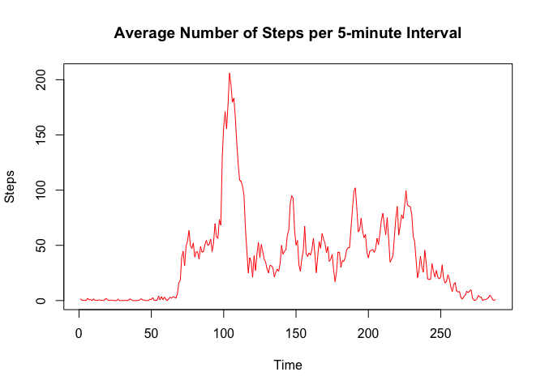

```r
StepsPerInterval <- aggregate(data=mydata, steps~interval, FUN=mean)
colnames(StepsPerInterval) <- c("Interval", "Steps")
with(StepsPerInterval, plot(Steps, type="l", main="Average Number of Steps per 5-minute Interval", xlab = "Time", ylab="Steps", col="red"))
```

Following this, calculate the time interval which contains the maximum number of steps

```r
StepsPerInterval %>% select(Interval, Steps) %>% filter(Steps==max(Steps))
```

```
##   Interval    Steps
## 1      835 206.1698
```

## Task 3: Imputing missing values

Calculate how many missing values are there in the entire dataset

```r
sum(is.na(mydata))
```

```
## [1] 2304
```

```r
mydata$newsteps <- ifelse(is.na(mydata$steps), mean(mydata$steps, na.rm=TRUE), mydata$steps)
```

Create a new dataset which is equal to the original dataset, but with the missing values filled in

```r
new_mydata <- data.frame(steps=mydata$newsteps, date=mydata$date, interval=mydata$interval)
head(new_mydata, n=6)
```

```
##     steps       date interval
## 1 37.3826 2012-10-01        0
## 2 37.3826 2012-10-01        5
## 3 37.3826 2012-10-01       10
## 4 37.3826 2012-10-01       15
## 5 37.3826 2012-10-01       20
## 6 37.3826 2012-10-01       25
```

Make a histogram of the total number of steps per day and calculate and report the mean and median number of steps per day

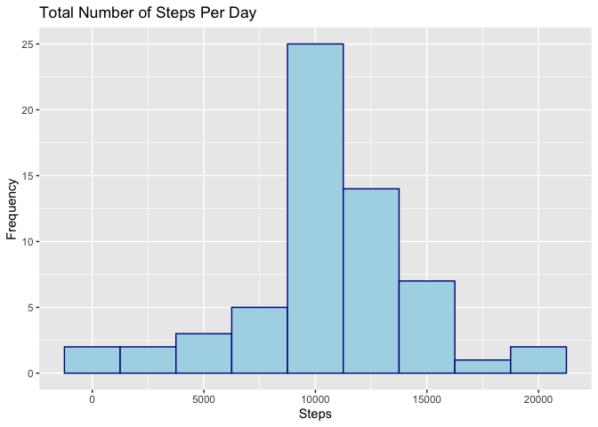

```r
NewStepsEachDay <- aggregate(new_mydata$steps, list(new_mydata$date), FUN=sum)
colnames(NewStepsEachDay) <- c("Date", "Steps")

g <- ggplot(NewStepsEachDay, aes(Steps))
g+geom_histogram(fill="light blue", col="dark blue", binwidth = 2500)+ggtitle("Total Number of Steps Per Day")+xlab("Steps")+ylab("Frequency")
```

Lastly, I calculated the mean and median values of total number of steps each day, for this new dataset

```r
mean(NewStepsEachDay$Steps)
```

```
## [1] 10766.19
```

```r
median(NewStepsEachDay$Steps)
```

```
## [1] 10766.19
```

## Task 4: Are there any differences in activity patterns between weekdays and weekends?

Firstly, create a new factor variable with two levels indicating ‘weekday’ and ‘weekend’

```r
new_mydata$date <- as.Date(strptime(new_mydata$date, format="%Y-%m-%d"))
new_mydata$day <- weekdays(new_mydata$date)

for (i in 1:nrow(new_mydata)) {
  if (new_mydata[i,]$day %in% c("Saturday","Sunday")) {
    new_mydata[i,]$day<-"weekend"
  }
  else{
    new_mydata[i,]$day<-"weekday"
  }}
head(new_mydata, n=6)
```

```
##     steps       date interval     day
## 1 37.3826 2012-10-01        0 weekday
## 2 37.3826 2012-10-01        5 weekday
## 3 37.3826 2012-10-01       10 weekday
## 4 37.3826 2012-10-01       15 weekday
## 5 37.3826 2012-10-01       20 weekday
## 6 37.3826 2012-10-01       25 weekday
```

Then, form a panel plot of 5-minute time interval (x axis) and average number of steps taken, averaged across all weekdays and weekends (y axis)

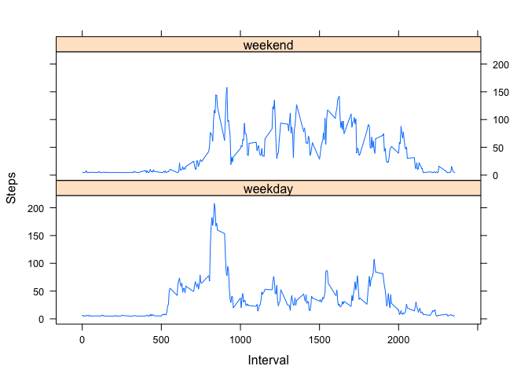

```r
NewStepsPerInterval <- aggregate(new_mydata$steps ~ new_mydata$interval + new_mydata$day, FUN=mean)
colnames(NewStepsPerInterval) <- c("Interval", "Day", "Steps")

xyplot(Steps ~ Interval | Day, NewStepsPerInterval, type="l", layout=c(1,2), xlab="Interval", ylab="Steps")
```